# Projekt z eksploracji danych

## 3.4 Success rate dla poszczególnych przedziałów zmiennych makroekonomicznych

Poniżej sprawdzamy jak poszczególne wartości wskaźników ekonomicznych wpływają na decyzję klienta o wzięciu lokaty terminowej:

**Emp.var.rate**

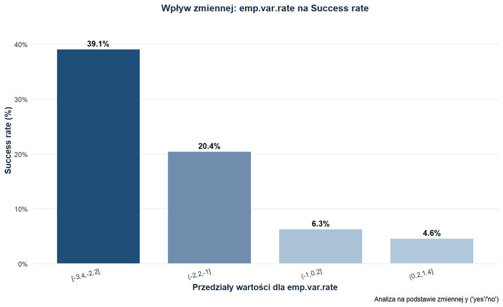

**Euribor 3M**

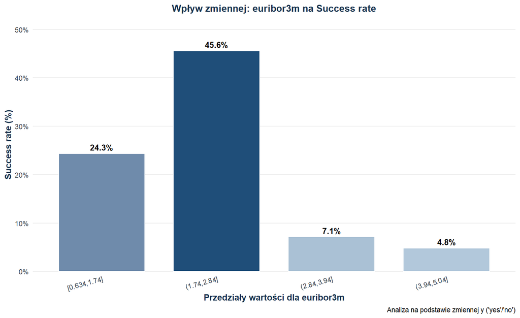

**Cons.conf.idx**

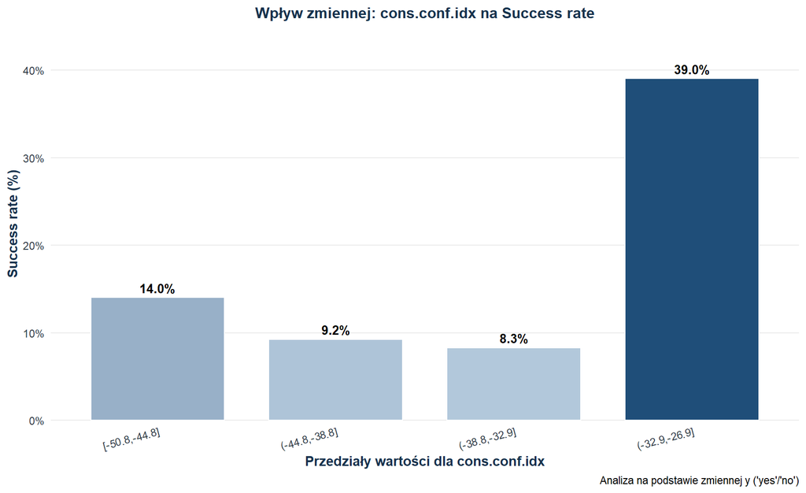

**Cons.price.idx**

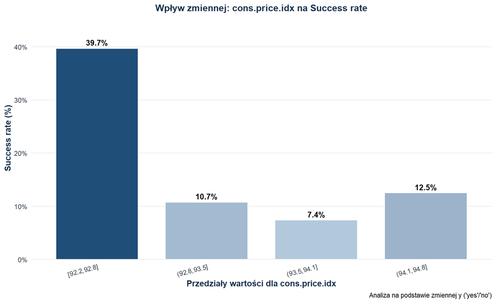

**Nr.employed**

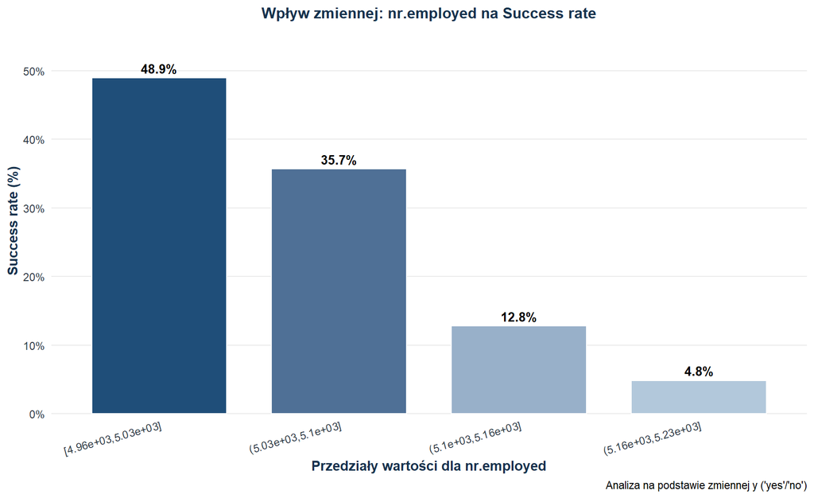

Możemy wywnioskowaćć, że:

- dla niższych wartości wskaźnika zmienności zatrudnienia mamy większą liczbę podpisanych lokat terminowych - może to wynikać z chęci klientów zabezpieczenia swoich oszczędności przed spadkiem ich wartości i zostawienia na lokacie pod korzystnym oprocentowaniem;
- przy umiarkowanych wartościach `euribor3m` klienci są bardziej skłonni do zakładania lokat terminowych;
- klienci również są bardziej skłonni do lokat, gdy mają dużą pewność w stabilnej sytuacji rynkowej oraz stopień inflacji jest stosunkowo niski;
- natomiast jednocześnie zakładają więcej lokat, gdy w kraju występuje niższa liczba osób zatrudnionych - może to sugerować większe zainteresowanie produktami oszczędnościowymi w okresach słabszej koniunktury gospodarczej.

Nie możemy również izolować wpływu poszczególnych wskaźników, bo są one ze sobą skorelowane. W naszym przypadku wyraźnie widać, że zmienne `emp.var.rate`, `euribor3m` i `nr.employed` opisują podobny aspekt koniunktury gospodarczej i wspólnie wskazują, że w okresach słabszej koniunktury klienci byli bardziej skłonni do zakładania lokat terminowych. Jednocześnie byli chętni to robić w sytuacjach dobrych nastrojów dotyczących sytuacji gospodarczej oraz niskiego poziomu inflacji. W naszych danych te fakty nie są sprzeczności. Bowiem w okresie od lipca 2009 roku do listopada 2009 roku współwystępują niski `emp.var.rate` i `cons.price.idx` oraz wysoki `cons.conf.idx`, co widać na wcześniej zaprezentowanych wizualizacjach.

# 4 Przygotowanie danych do dalszego procesu modelowania

Najpierw dzielimy dane na zbiory treningowy, walidacyjny i testowy, aby podczas przygotowania danych nie dopuścić do statystycznego przecieku informacji ze zbioru testowego do treningowego.

Głównym celem projektu jest klasyfikacja klienta, czyli ocena, czy osoba o danym profilu założy lokatę terminową. Z tego względu stosujemy losowy podział stratyfikowany według zmiennej `y`, aby zbiór treningowy i testowy zachowały podobny udział klasy pozytywnej `yes`. Wstępny podział chronologiczny wskazywał na silną zmianę udziału sukcesów w kolejnych częściach zbioru, co odpowiadałoby raczej zadaniu prognozowania przyszłych okresów kampanii niż klasycznej predykcji klienta.

W walidacji modeli stosujemy pięciokrotną walidację krzyżową ze stratyfikacją. Pozwala to stabilniej porównać modele przy niezbalansowanej zmiennej wynikowej i zachować podobny udział klasy `yes` w każdym foldzie.

Podział na train/test przeprowadzamy przed wszelkimi modyfikacjami i imputacjami, aby nie napotkać problemu przecieku danych pomiędzy tymi zbiorami. Do pracy z modelami wykorzystujemy framework `tidymodels` . W nim operacje takie jak MICE czy PCA zadeklarowane w `recipe` automatycznie uczą się parametrów wyłącznie na podzbiorach treningowych danego foldu, a na walidacji/teście są tylko aplikowane.

Standaryzację przeprowadzono wyłącznie dla zmiennych wykorzystywanych w PCA. Po utworzeniu komponentów głównych nie wykonywano dalszej normalizacji zmiennych zero-jedynkowych, ponieważ taka transformacja utrudnia interpretację i nie jest wymagana przez większość rozważanych modeli.

W procesie trenowania wszystkie modele będą oceniane w oparciu o walidację krzyżową na zbiorze treningowym. Po wyborze najlepszego modelu względem metryki ROC AUC, dokonana zostanie jego finalizacja (trenowanie na pełnym zbiorze treningowym) oraz ocena na zbiorze testowym. Wszystkie wyniki (metryki CV, predykcje, parametry) są zapisane, co pozwala na pominięcie ponownego trenowania modeli.

# 5 Budowa, trenowanie oraz wstępne porównanie wybranych modeli uczenia maszynowego

W tej części porównujemy kilka rodzin modeli uczenia maszynowego. Wcześniejsze uruchomienie treningu zostało zapisane do plików `.rds`, dlatego poniższy raport nie trenuje ponownie wszystkich modeli. Dzięki temu możemy odtworzyć ranking, wykresy i predykcje dokładnie z zapisanych wyników, bez wielogodzinnego ponownego strojenia hiperparametrów.

W modelowaniu wykorzystano regresję logistyczną z regularyzacją, drzewo decyzyjne, las losowy, XGBoost oraz prostą sieć neuronową. Wszystkie modele korzystały z tej samej receptury przygotowania danych, co pozwala porównywać ich wyniki w uczciwy sposób.

| Model | Testowane konfiguracje | Odrzucone przez ANOVA race | % odrzuconych | Liczba foldów | Łączna liczba treningów |
| --- | --- | --- | --- | --- | --- |
| XGBoost | 1 | 14 | 93% | 5 | 5 |
| Sieć neuronowa | 2 | 13 | 87% | 5 | 10 |
| Las losowy | 2 | 13 | 87% | 5 | 10 |
| Drzewo decyzyjne | 12 | 3 | 20% | 5 | 60 |
| Regresja logistyczna | 13 | 2 | 13% | 5 | 65 |
| RAZEM | 30 | 45 | 60% | NA | 150 |

Ostatecznie przeprowadzono 150 treningów wybranych modeli z różnymi parametrami stosując przeszukiwanie z pomocą hipersześcianu łacińskiego. Metoda wyścigów pozwoliła przyspieszyć wybór optymalnych modeli, odrzucając 45 zestawów hiperparametrów, które nie przyniosłyby poprawy, co zmniejszyło liczbę przeprowadzanych treningów o 225.

## 5.1 Najlepsze konfiguracje modeli

Poniżej pokazano najlepszą konfigurację każdego modelu wybraną według metryki ROC AUC. Nie wszystkie kolumny dotyczą każdego modelu, ponieważ różne algorytmy mają różne hiperparametry.

Najlepsze hiperparametry poszczególnych modeli

| penalty | mixture | .config | Model | tree_depth | min_n | mtry | learn_rate | loss_reduction | hidden_units |
| --- | --- | --- | --- | --- | --- | --- | --- | --- | --- |
| 0.00139 | 0.66071 | pre0_mod11_post0 | Regresja logistyczna | NA | NA | NA | NA | NA | NA |
| NA | NA | pre0_mod04_post0 | Drzewo decyzyjne | 4 | 37 | NA | NA | NA | NA |
| NA | NA | pre0_mod04_post0 | Las losowy | NA | 37 | 11 | NA | NA | NA |
| NA | NA | pre0_mod14_post0 | XGBoost | 9 | 37 | NA | 0.01778 | 4.77058 | NA |
| 0.19307 | NA | pre0_mod04_post0 | Sieć neuronowa | NA | NA | NA | NA | NA | 2 |

## 5.2 Wstępne porównanie modeli

ROC AUC informuje, jak dobrze model szereguje klientów od najbardziej do najmniej prawdopodobnych do założenia lokaty. Jest to wygodna metryka porównawcza, ale przy niezbalansowanych klasach warto patrzeć również na PR AUC, precyzję, czułość i F1.

**Ranking ROC AUC**

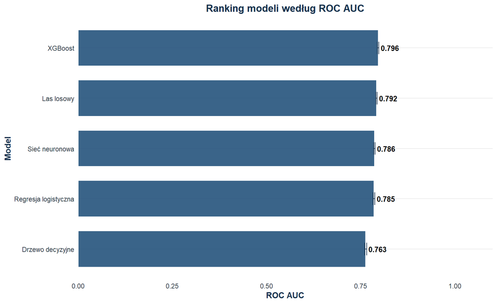

**Metryki CV**

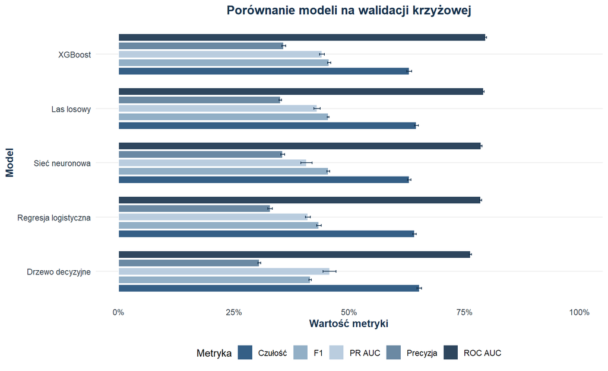

**Tabela wyników**

Metryki najlepszych konfiguracji modeli w walidacji krzyżowej

| Model | Metryka | Średnia | Błąd standardowy |
| --- | --- | --- | --- |
| Drzewo decyzyjne | ROC AUC | 0.7629 | 0.0027 |
| Drzewo decyzyjne | Czułość | 0.6521 | 0.0047 |
| Drzewo decyzyjne | PR AUC | 0.4576 | 0.0142 |
| Drzewo decyzyjne | F1 | 0.4156 | 0.0028 |
| Drzewo decyzyjne | Precyzja | 0.3051 | 0.0029 |
| Regresja logistyczna | ROC AUC | 0.7852 | 0.0022 |
| Regresja logistyczna | Czułość | 0.6419 | 0.0037 |
| Regresja logistyczna | F1 | 0.4345 | 0.0048 |
| Regresja logistyczna | PR AUC | 0.4106 | 0.0052 |
| Regresja logistyczna | Precyzja | 0.3286 | 0.0053 |
| Sieć neuronowa | ROC AUC | 0.7862 | 0.0020 |
| Sieć neuronowa | Czułość | 0.6303 | 0.0035 |
| Sieć neuronowa | F1 | 0.4548 | 0.0031 |
| Sieć neuronowa | PR AUC | 0.4074 | 0.0122 |
| Sieć neuronowa | Precyzja | 0.3558 | 0.0042 |
| Las losowy | ROC AUC | 0.7917 | 0.0016 |
| Las losowy | Czułość | 0.6459 | 0.0041 |
| Las losowy | F1 | 0.4545 | 0.0020 |
| Las losowy | PR AUC | 0.4303 | 0.0068 |
| Las losowy | Precyzja | 0.3506 | 0.0025 |
| XGBoost | ROC AUC | 0.7960 | 0.0019 |
| XGBoost | Czułość | 0.6306 | 0.0054 |
| XGBoost | F1 | 0.4566 | 0.0035 |
| XGBoost | PR AUC | 0.4411 | 0.0053 |
| XGBoost | Precyzja | 0.3580 | 0.0043 |

Jak widać, w ok. 79% XGBoost i las losowy losowej obserwacji o klasie pozytywnej przypiszą właśnie klasę pozytywną o wiele częściej niż klasę negatywną.

PR-AUC natomiast skupia się na pozytywnej klasie - co jest dla nas ważne, ponieważ chcemy poprawnie wskazywać klientów, którzy założą lokatę terminową. Metryka ta została wybrana jako uzupełnienie ROC-AUC. Największa wartość tej metryki przyjmuje drzewo decyzyjne, natomiast ma ono stosunkowo niską wartość precyzji.

Wszystkie modele mają dobry poziom czułości kosztem precyzji. Z tego względu cierpi również wartość F1-score.

Podsumowując, dla wszystkich modeli dobrze rozróżniamy klasy (na co wskazuje wartość ROC-AUC), natomiast gorzej wykrywamy klasę pozytywną (wartości PR-AUC w granicach 0.4-0.45 dla wszystkich modeli). Czułość bowiem ma o wiele wyższą wartość niż precyzja. Czyli dobrze wykrywamy klasę pozytywną ze wszystkich obserwacji mających klasę pozytywną, natomiast poprawność wykryć pozytywnej klasy nie jest zadowalająca.

Najlepszy model w dalszej części raportu wybieramy według ROC AUC. Dodatkowe metryki pozwalają jednak sprawdzić, czy model nie osiąga dobrego rankingu kosztem bardzo słabego rozpoznawania klasy `yes`.

# 6 Ewaluacja modeli uczenia maszynowego oraz ich kalibracja

Po wyborze najlepszego modelu korzystamy z zapisanej ewaluacji na zbiorze testowym. Zbiór testowy jest traktowany jako końcowa, jednorazowa ocena jakości modelu, dlatego nie wykorzystujemy go do strojenia hiperparametrów.

Metryki XGBoost jako finalnego modelu na zbiorze testowym

| Metryka | Estymator | Wynik |
| --- | --- | --- |
| Accuracy | binary | 0.8367 |
| ROC AUC | binary | 0.8044 |
| brier_class | binary | 0.1625 |

Dokładność modelu wynosi 0.837, ale nie powinna być główną podstawą oceny, ponieważ dane są silnie niezbalansowane, a klasa negatywna stanowi około 88.7% zbioru testowego. ROC-AUC na poziomie 0.804 wskazuje na umiarkowanie dobrą zdolność porządkowania klientów według prawdopodobieństwa założenia lokaty. Jednocześnie PR-AUC równe 0.461, precyzja 0.368, czułość 0.627 i F1 równe 0.464 pokazują kompromis: model wykrywa istotną część klientów z klasy `yes`, ale generuje też sporo fałszywych alarmów. Wartość Brier score równa 0.163 można uznać za umiarkowaną, lecz sama w sobie nie dowodzi dobrej kalibracji prawdopodobieństw.

Wybrany model nie wskazuje oznak przeuczenia, ponieważ wartość ROC-AUC uzyskana na zbiorze testowym jest zbliżona do wartości tejże metryki uzyskanej podczas 5-krotnej walidacji krzyżowej. Wskazuje to na to, że model dobrze sobie radzi z niewidzianymi wcześniej danymi.

## 6.1 Macierz pomyłek

Macierz pomyłek pokazuje, ile obserwacji zostało przypisanych do poprawnych i błędnych klas. W tym projekcie szczególnie ważne są pomyłki dotyczące klasy `yes`, ponieważ to ona odpowiada klientom potencjalnie zainteresowanym lokatą.

Macierz pomyłek finalnego modelu

| Prawdziwa | Predykcja | Freq |
| --- | --- | --- |
| yes | yes | 582 |
| no | yes | 999 |
| yes | no | 346 |
| no | no | 6309 |

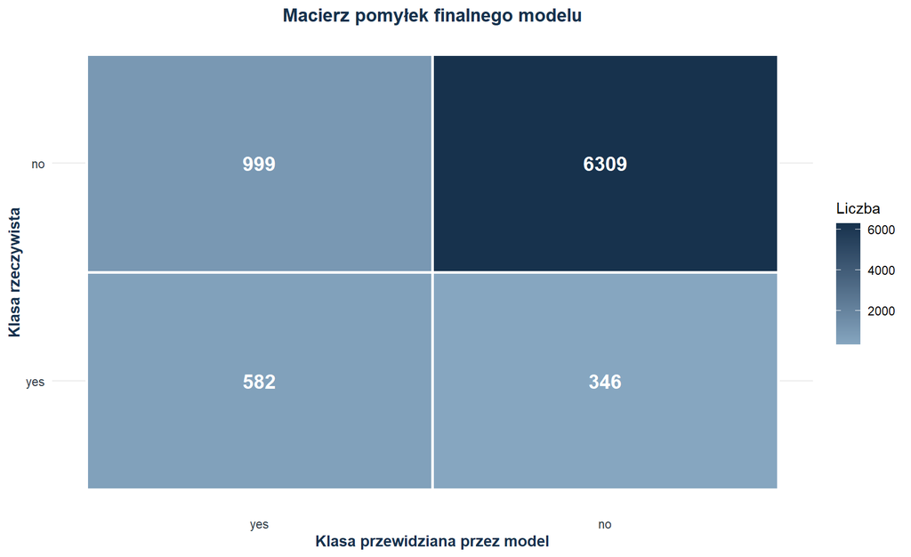

Widzimy poprawne zaklasyfikowanie 6309 obserwacji jako klasa negatywna oraz 582 jako klasa pozytywna. Model również popełnia błędy - 999 obserwacji o klasie negatywnej są zaklasyfikowane jako klasa pozytywna,, a 346 obserwacji o klasie pozytywnej - jako negatywna. Obniżenie progu klasyfikacyjnego pozwoliłoby zwiększyć czułość modelu i zmniejszyć liczbę błędów FN.

## 6.2 Krzywe ROC, PR i kalibracja

Krzywa ROC pokazuje kompromis między wykrywaniem klasy pozytywnej i fałszywymi alarmami dla różnych progów decyzyjnych. Krzywa PR jest szczególnie przydatna przy niezbalansowanych klasach, bo skupia się na jakości przewidywania klasy `yes`. Kalibracja sprawdza natomiast, czy przewidywane prawdopodobieństwa są zgodne z rzeczywistym udziałem sukcesów.

**ROC**

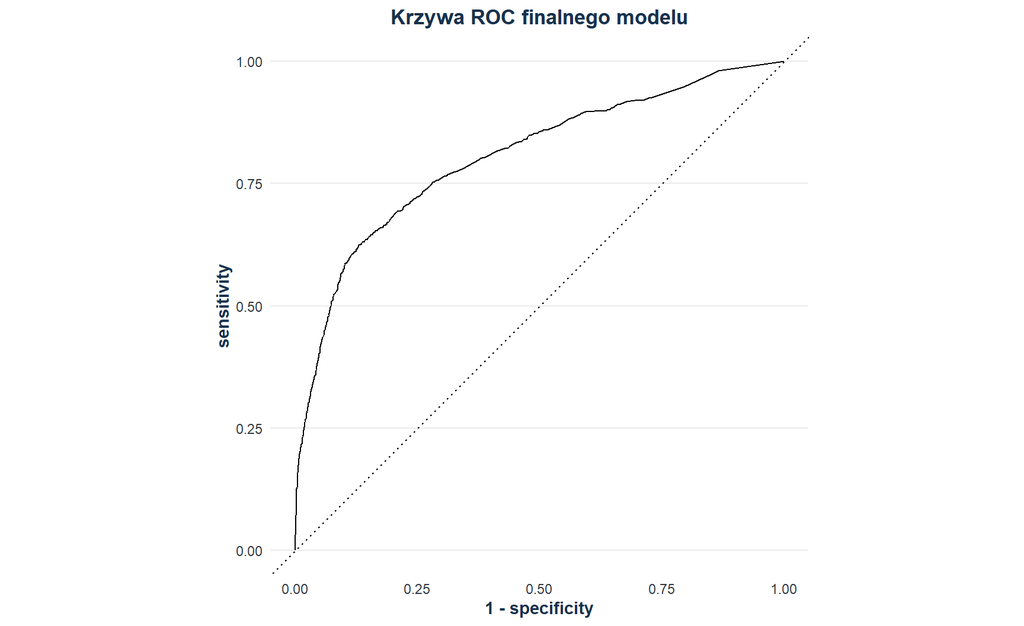

**Precision-Recall**

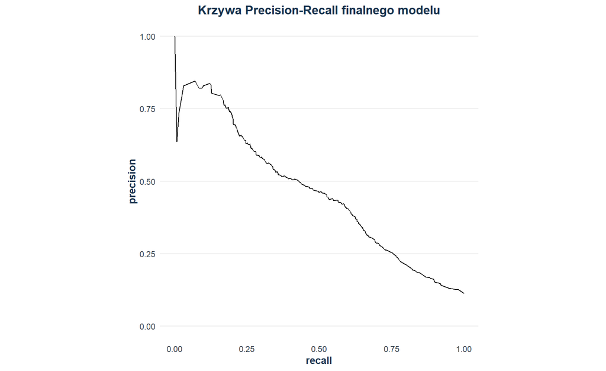

**Kalibracja**

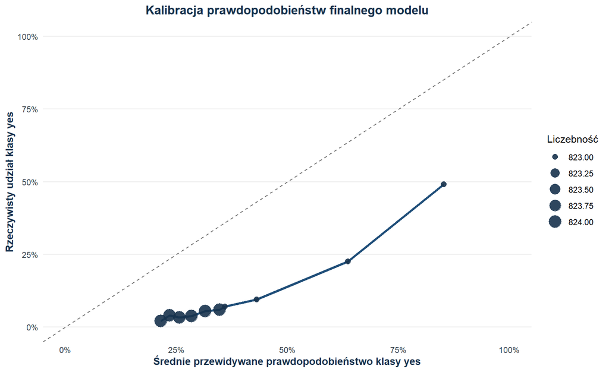

Model osiąga sensowną, ale umiarkowaną jakość rankingu, co widać na krzywej ROC oraz wartości ROC-AUC. Krzywa Precision-Recall pokazuje natomiast, że wyższą precyzję można uzyskać kosztem niższej czułości, czyli mniejszej liczby poprawnie wykrytych klientów z klasy `yes`. Z wykresu kalibracji wynika, że model zawyża prawdopodobieństwa klasy `yes`: rzeczywisty udział tej klasy jest niższy od średnich przewidywanych prawdopodobieństw, dlatego krzywa leży poniżej linii idealnej `y = x`.

# 7 Przeprowadzenie analizy popełnianych błędów przez wykorzystane modele predykcyjne

Sama wartość metryki nie mówi jeszcze, gdzie model się myli. Dlatego poniżej rozdzielamy predykcje na cztery grupy: poprawnie rozpoznane sukcesy, poprawnie rozpoznane odmowy, fałszywe alarmy oraz przeoczone sukcesy.

Typy poprawnych i błędnych decyzji finalnego modelu

| error_type | n | udzial |
| --- | --- | --- |
| TP: poprawnie wykryte yes | 582 | 0.0707 |
| TN: poprawnie wykryte no | 6309 | 0.7660 |
| FP: fałszywy alarm | 999 | 0.1213 |
| FN: przeoczony sukces | 346 | 0.0420 |

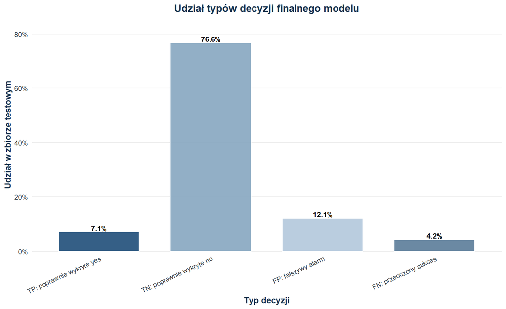

Jak widać, model dobrze rozpoznaje klasę negatywną, co nie jest dziwne, ponieważ ma znaczącą przewagę liczebną w zbiorze danych. Model bowiem zaklasyfikował poprawnie 76,6% klientów do klasy negatywnej, a źle względem tej klasy - 12,1% klientów.

Model nie wychwycił 4,2% klientów zainteresowanych założeniem lokaty. Idealnie byłoby zniwelować ten rodzaj błędu. Moglibyśmy go zminimalizować zmnniejszając próg klasyfikacyjny.

Najbardziej praktyczne są dwie grupy błędów: `FP`, czyli klienci wskazani jako potencjalnie zainteresowani, którzy faktycznie nie założyli lokaty, oraz `FN`, czyli klienci zainteresowani lokatą, których model nie wychwycił. Pierwszy typ może oznaczać niepotrzebny kontakt, drugi utraconą szansę sprzedażową.

**Zawód**

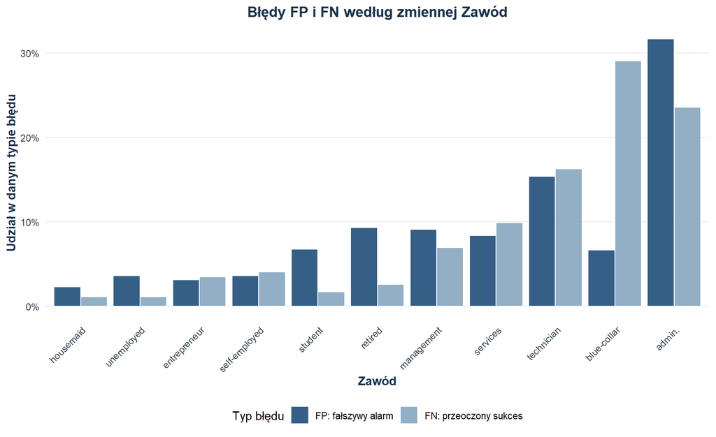

**Wykształcenie**

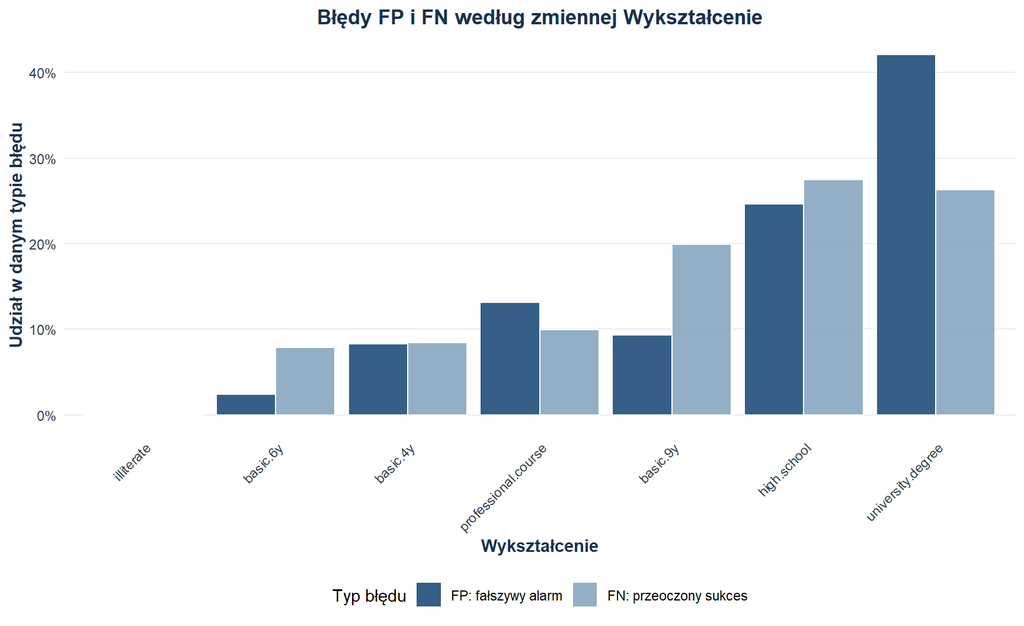

**Wynik poprzedniej kampanii**

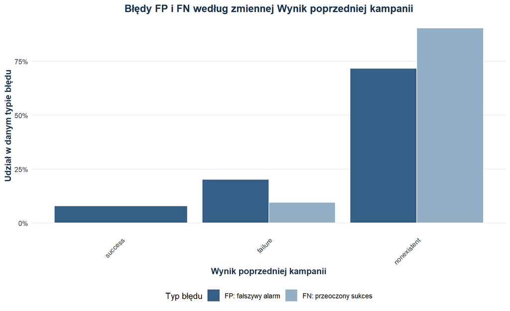

**Kontakt wcześniejszy**

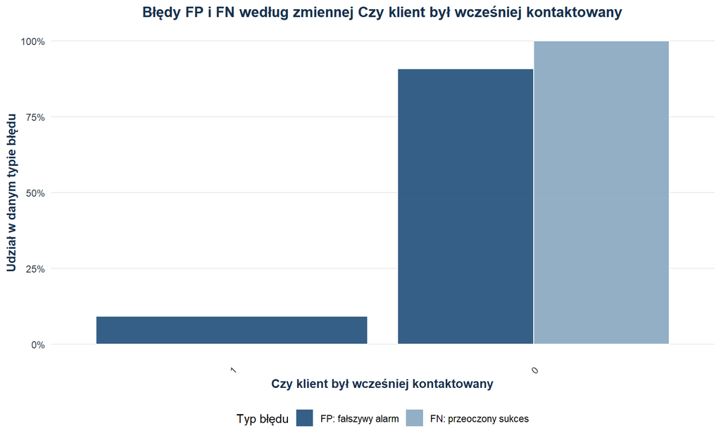

Wśród błędów FN częściej pojawiają się pracownicy fizyczni, technicy oraz osoby pracujące w sektorze usług. Podobny wzorzec widać dla osób z podstawowym, 9-letnim wykształceniem oraz dla klientów bez wcześniejszego kontaktu, oznaczonych jako `nonexistent` w wyniku poprzedniej kampanii, co jest spójne z błędami widocznymi przy zmiennej `was_contacted_before`. Wśród błędów FP częściej pojawiają się natomiast studenci, emeryci, osoby ze studiami wyższymi oraz klienci, którzy nie założyli lokaty w trakcie poprzedniej kampanii.

Model częściej wskazuje fałszywe alarmy także wśród klientów, z którymi wcześniej się kontaktowano. Można więc przypuszczać, że wcześniejszy kontakt jest dla modelu silnym sygnałem zainteresowania, ale nie zawsze przekłada się na rzeczywiste założenie lokaty.

# 8 Analiza wyjaśnialności decyzji modeli predykcyjnych

Wyjaśnialność traktujemy jako wsparcie interpretacji modelu. Nie oznacza ona automatycznie zależności przyczynowej, ale pomaga zobaczyć, które cechy były dla finalnego modelu najbardziej użyteczne przy rozróżnianiu klientów. Do wyjaśnienia decyzji modelu wykorzystamy permutacyjną ważność cech modeli drzewiastych.

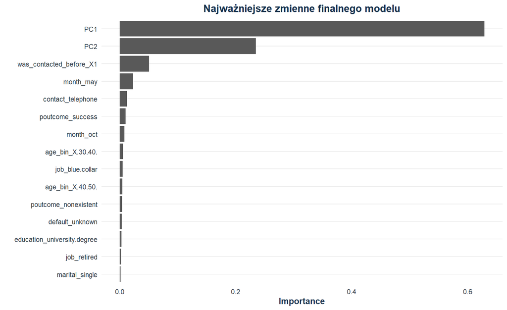

Potwierdzamy, że jeden z największych wpływów wywarła zmienna `was_contacted_before` o wartości 1. Ponadto znaczący wpływ na decyzje klienta ma obecna sytuacja gospodarcza. Co ciekawe maj też wpływa na decyzję, sposób kontaktu oraz pozytywny wynik kampanii marketingowej dla danego klienta.

# 9 Podsumowanie i sformułowanie wniosków

Przeprowadzona analiza pokazuje pełny proces budowy modelu klasyfikacyjnego: od przygotowania danych, przez porównanie kilku rodzin modeli, po finalną ocenę na zbiorze testowym. Najważniejsze było zachowanie spójności celu projektu z walidacją: model ma rozpoznawać klientów podobnych do tych z dostępnych danych, dlatego zastosowano podział stratyfikowany i metryki odpowiednie dla klasy `yes`.

Wyniki modeli należy interpretować łącznie. ROC AUC pokazuje ogólną zdolność rankingu klientów, PR AUC jest bardziej wymagające przy rzadkiej klasie pozytywnej, a precyzja i czułość mówią o praktycznych kosztach decyzji. Jeżeli model ma być używany w kampanii marketingowej, próg decyzyjny można później dostosować do celu biznesowego: większa czułość pozwala znaleźć więcej potencjalnych klientów, ale zwykle zwiększa liczbę fałszywych alarmów.

Analiza błędów wskazuje, w jakich grupach model częściej myli się przy klasie `yes`. To miejsce jest szczególnie przydatne do dalszej pracy, ponieważ pokazuje, czy model przeocza konkretne typy klientów albo zbyt często oznacza jako zainteresowanych klientów z określonych segmentów.

# 10 Podstawowe wdrożenie modelu wybranego na podstawie przeprowadzonej ewaluacji oraz test predykcyjny

Na końcu sprawdzamy, jak wyglądałoby podstawowe użycie modelu. W praktyce bank mógłby przekazać do modelu dane klienta przed kontaktem, a model zwróciłby przewidywaną klasę oraz prawdopodobieństwo założenia lokaty. Takie prawdopodobieństwo może pomóc w priorytetyzacji kontaktów, ale nie powinno być jedyną podstawą decyzji biznesowej.

Przykładowy test predykcyjny finalnego modelu na obserwacjach ze zbioru testowego

| age_bin | job | education | poutcome | contact | was_contacted_before | Rzeczywista decyzja | Prawdopodobieństwo yes | Prawdopodobieństwo no | Predykcja modelu |
| --- | --- | --- | --- | --- | --- | --- | --- | --- | --- |
| (40,50] | blue-collar | NA | nonexistent | telephone | 0 | no | 0.2149 | 0.7851 | no |
| (30,40] | admin. | university.degree | nonexistent | cellular | 0 | no | 0.3035 | 0.6965 | no |
| (25,30] | unemployed | basic.4y | success | cellular | 1 | no | 0.9160 | 0.0840 | yes |

Powyższa tabela pokazuje minimalny wariant wdrożenia: dla kilku klientów model zwraca klasę oraz prawdopodobieństwo klasy `yes`. W prawdziwym zastosowaniu taki wynik można połączyć z progiem decyzyjnym, np. kontaktować się najpierw z klientami o najwyższym prawdopodobieństwie pozytywnej odpowiedzi.